# Rodent trapping studies to understand the prevalence of zoonotic disease in West Africa: A scoping review.

true  
2021-08-31

# Introduction

- The role of zoonotic infectious diseases in human health and society have been dramatically highlighted through the ongoing SARS-CoV-2 pandemic and recent Ebola virus outbreaks in the Democratic Republic of Congo and Guinea.
- The number and intensity of zoonotic spillover events is projected to increase under anthropogenic pressure (e.g. increased human populations and increasing urbanisation) and global climate change (Morse et al. 2012).
- Rodents are abundant and diverse (Burgin et al. 2018), their widespread occurrence and proximity to human activity make the understanding of the effect of environmental change on their host-pathogen interactions vitally important.
- Rodents are important hosts of zoonotic disease. Of 2,220 extant rodent species, 244 (10.7%) are described as being reservoirs of 85 zoonotic pathogens (Han, Kramer, and Drake 2016). This is an example of an ecosystem disservice provided by rodents.
- Rodents, however, also provide important ecosystem services within these habitats, including, pest regulation and seed dispersal (Fischer et al. 2018).
- Rodents typically demonstrate “fast” life histories (Dobson and Oli 2007) and within rodents, these traits are associated with a species being a reservoir of zoonotic diseases (Han et al. 2015), but see (Albery and Becker 2021). Further, these traits are prevalent in species that thrive in human dominated landscapes, displacing species that are less likely to be reservoirs of zoonotic disease (Gibb et al. 2020).
- West Africa has previously been identified to be at relatively high risk of emerging zoonotic infectious disease events from wildlife populations (Jones et al. 2008). Ongoing changes in land use and population demographics may lead to an increased burden from zoonotic diseases.
- Rodents are implicated in the transmission pathways of several diseases in the region, including, Lassa fever, Schistosomiasis and Leptospirosis.
- Studies have been conducted in West Africa both to identify novel potential zoonotic pathogens within rodents alongside studies investigating the prevalence and burden of known pathogens within rodent hosts (e.g. for Lassa fever (Fichet-Calvet et al. 2009) and Schistosomiasis (Catalano et al. 2020)).
- Our understanding of the associations between rodents and their pathogens on broader geographic scales are typically based on global datasets (e.g. PREDICTS, GIDEON and GBIF) that consolidate information obtained from multiple sources of information (Gibb et al. 2020; Smith et al. 2014; Pigott et al. 2014). These datasets may lack the contextually rich information on the presence, absence and abundance of individual species and the habitats in which they were trapped that is potentially provided by individual rodent trapping studies (Bovendorp, MCCleery, and Galetti 2017).
- Alongside disease specific studies these datasets have been used to identify potential geographic hotspots where virus and host species diversity may be expected to be at its greatest and therefore quantify the risk of a zoonotic disease spillover event occurring at a defined location (Han, Kramer, and Drake 2016). However, there remains the potential for important confounding introduced to these associations through bias generated by study design or through selection of sampling sites.
- For example, systematically increased sampling (e.g. more intensive studies over longer time periods) or over-representation of certain habitats (e.g. periurban landscapes) could lead to an apparent association between locations and risk that is driven by these factors rather than an underlying host and virus association (Wille, Geoghegan, and Holmes 2021; Gibb et al. 2021).
- Conversely some regions may not be sampled adequately and therefore under-represented in these datasets due to sparse human populations or inaccessible habitats which may lead to erroneously identifying regions as low risk of zoonotic disease spillover events.
- Here, we identify rodent trapping studies performed across West Africa and identify the location and habitat types in which they have been conducted, the pathogens assessed and the host-pathogen associations that have been reported in order to quantify the potential bias and identify areas requiring further focussed investigation.

# Methods

## Literature search

- We conducted a search in Ovid MEDLINE, Web of Science (Core collection and Zoological Record), JSTOR, BioOne, African Journals Online, Global Health and the pre-print servers, BioRxiv and EcoEvoRxiv for the following terms as keywords, no date constraints were used:
  1. Rodent OR Rodent trap*
  2. West Africa (or the individual countries)
  3. 1. AND 2.
- We searched other resources including the UN Official Documents System, Open Grey, AGRIS FAO and Google Scholar using combinations of the above terms.
- We ran the search on 2021-03-01.
- We included studies if they met all of the following inclusion criteria; i) reported findings from trapping studies where the target was a small mammal, ii) described the type of trap used or the length of trapping activity or the location of the trapping activity, iii) included trapping activity from at least one West African country, iv) recorded the genus or species of trapped individuals, v) were published in a peer-reviewed journal or as a pre-print on a digital platform or as a report by a credible organisation.
- We excluded studies if they met any of the following exclusion criteria: i) reported data that were duplicated from a previously included study, ii) no full text available, iii) not available in English.
- One reviewer screened titles, abstracts and full texts against the inclusion and exclusion criteria. At each stage, a random subset (10%) was reviewed by a second reviewer.

## Data extraction

- We extracted data from eligible studies to input into a Google sheets document. Extracted variables included i) study identifiers; ii) study aims; iii) trapping methodology; iv) geolocation data; v) method of speciation; vi) trapping locations and dates; vii) trapped species; viii) number of trap-nights and ix) microorganisms/pathogens of interest. The data extraction tool is archived and available in Supplementary Material 1.

### Location of rodent trapping studies and habitats studied

- We extracted GPS locations for the most precise location presented (i.e. trap, trap-line, study site or study region). We extracted coordinates in the format reported, subsequently converting them to decimal degrees.
- We recorded the habitat classification scheme a study used (e.g. IUCN Habitat Classification Scheme (Version 3.1)). For studies not using standardised recording, the explicit description from of the habitat in which the trap was placed was extracted. For studies reporting multiple habitat types (e.g. rice field, corn field and vegetable garden) for a single trap, trap-line or trapping grid, a higher order classification of habitat type was recorded (e.g. agricultural land).

### Rodent presence, absence, abundance

- We mapped genus and species names to the species names used in the GLobal Biodiversity Information Facility (GBIF) taxonomy (Facility 2021)
- We extracted information on the presence, absence and number of trapped individuals. For studies reporting on all trapped individuals (i.e. not those only reporting on the presence of a specific species of interest), the pseudo-absence of a species reported as present elsewhere in the study was explicitly recorded as an absence at that trap location.

### Pathogen presence and absence

- We extracted data on all pathogens assayed for in studies investigating rodents for potential zoonoses. The number of rodents tested and the number of positive or negative samples were recorded alongside the type of assay used (e.g. Polymerase Chain Reaction (PCR), Enzyme Linked ImmunoSorbent Assay (ELISA) or viral culture). If studies reported indeterminate results this was noted. Where possible, pathogens were identified to species level. However, where an assay only allowed for attribution to a family of viruses or bacteria, the higher order grouping was used (i.e. PCR using a non-specific arenavirus primer).

## Analysis

### Location and habitats of rodent trapping to investigate potential biases

- We summarised the number of studies, the year in which trapping occurred and the country in which they were conducted. In studies not reporting the year of trapping we used the year of publication as a proxy.
- We used the GPS coordinates of single trap, trapping grid/line or study site and the number of trap nights to calculate trapping effort (trap night density) within level 2 administrative areas in West Africa.
- For studies not reporting the number of trap nights we imputed the number based on the median trap success rate from studies which reported the number of trap nights (matched to building or non-building based study sites). The median trap success rate for all rodents at a defined trap site was calculated for both trap sites including built environments and non-built environments. The number of rodents trapped at a trap site was then used in combination with these values of trap success to impute the number of trap nights for trap sites with no reported trap nights.
- We summarised the habitat types of trap sites based on information reported in the study.
- For the subset of studies investigating rodent zoonoses we compared the location of trapping sites with 2005 SEDAC Global Population Density estimates, the median year studies were commenced, using a Generalised Additive Model (GAM) incorporating a spatial interaction term to investigate the association of number of trap nights and human population density. The model structure was specified as below:
  - *trap night density* ~ *Tweedie*(*log*(Population density (2005)) + (Longitude * Latitude))
- We repeated this approach for land cover classifications obtained from the European Space Agency Copernicus dataset (2005) using a GAM incorporating a spatial interaction term to investigate the association of trap nights and land cover.
- We mapped the presence and absence of rodent species and compared this to the presence and absence reported by both GBIF and IUCN to give a measure of the extent of each species range in which they have been sampled.

### Rodent pathogen associations

- We summarised the presence and absence of pathogens, the assays used, their host species and the locations from where the samples were obtained.
- We investigated the association between rodent species and the detection of potential pathogens. We report proportion of positive and negative tests for each species and pathogen pair.

# Results

## Included studies

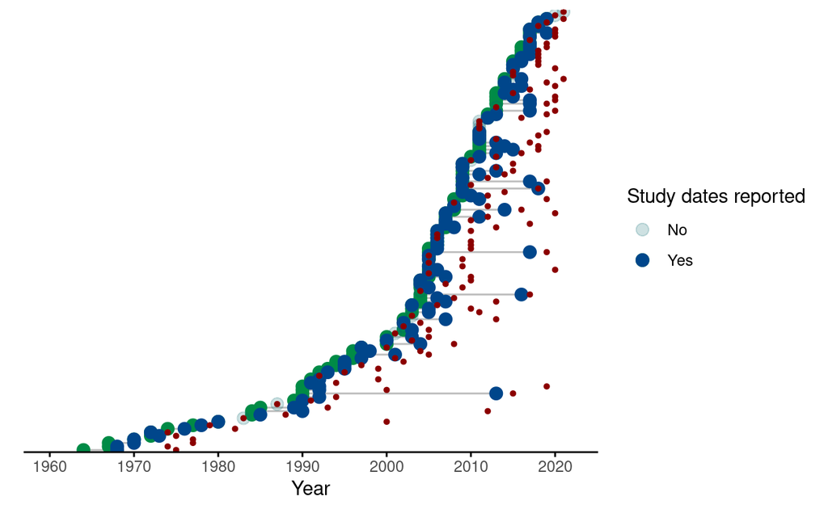

*Figure 1*: Each row represents one of the 126 included studies, green points designate the first year of data collection, blue points designate the end of data collection. For studies completed within one year the blue point completely overlies the green. Studies with a transparent grey point did not report the year in which trapping was conducted. The year of publication is shown by a red point.

## Location and habitats of rodent trapping studies to investigate potential biases

[figure not shown]

*Figure 2*: **Panel A:** Map of West Africa, countries where rodent trapping has occurred are mapped to level 2 administrative areas (where available). These regions are coloured by the total number of trap nights performed at trap sites within their boundaries. **Panel B:** (n.b. will not include map in final manuscript) The number of trap nights conducted is associated with a regions population density. The population density for all regions in West Africa is shown in the yellow box plot, the population density and trap night density for each region is show on the purple scatterplot. The line of best fit is a GAM model not incorporating spatial interactions. The map panel on the right is the product of the GAM model incorporating spatial interactions. **Panel C:** Histogram of habitat types at 1km<sup>2</sup> resolution across West Africa and for areas where trapping has occurred.


## Host-pathogen associations

- Ninety-seven rodent species were investigated for the presence of a zoonotic pathogen. 42,940 assays were performed on 32,014 individual rodents.
- The rodent species most commonly assayed for zoonotic pathogens were, Rattus rattus (n = 2,977) assessed for 24 pathogens, Mus musculus (n = 3,402) for 23, Mastomys natalensis (n = 7,189) and Mastomys erythroleucus (n = 3,013) both 19 and Arvicanthis niloticus (n = 3,840) for 18. * All remaining species were investigated for 10 or fewer pathogens.
- Lassa mammarenavirus was detected in 414 Mastomys natalensis, 9 Mastomys erythroleucus, 5 Hylomyscus pamfi and 3 Mus baoulei through PCR. In serological assays, evidence of prior infection or acquisition of maternal antibodies to Lassa mammarenavirus was found in 465 Mastomys natalensis, 361 Mastomys sp., 6 Mus musculus and 4 Rattus rattus. From direct viral culture 19 Mastomys natalensis, 2 Rattus rattus and 1 Mus minutoides were found to be infected with Lassa mammarenavirus. Bartonella sp. were detected in; 113 Mastomys natalensis, 50 Mastomys erythroleucus, 39 Rattus norvegicus, 16 Rattus rattus and 13 individuals of 7 further species through PCR.
- Borrelia sp. infections were identified through PCR in 110 individuals; 37 Mastomys erythroleucus, 12 Mus musculus, 11 Mastomys huberti and Praomys daltoni., tThe remaining 39 positive results were from 9 further species. In serological assays, 47 Mastomys natalensis, 12 Mastomys erythroleucus and 8 Praomys daltoni were found to be positive, the remaining 11 positive individuals came from three further species. Most Borrelia sp. infections were identified through histology or direct visualisation with, 243 Arvicanthis niloticus, 102 Mastomys natalensis, and 78 Mastomys huberti along with a further 64 individuals from 8 species infected.
- Finally, Toxoplasma gondii was detected via PCR in 89 Mus musculus, 13 Cricetomys gambianus, 5 Crocidura olivieri and 3 Rattus rattus. From serological assays evidence of infection was found in 25 Mus musculus, 46 Mastomys erythroleucus, 4 Rattus rattus, and Mastomys natalensis, using histology and direct visualisation 1 Mus musculus and 1 Rattus rattus were also found to be infected.
- Thirty-eight species of Rodentia, 3 species of Soricomorpha and 2 species of Erinaceomorpha that were tested for potential pathogens had entirely negative results.

## Discussion

Albery, Gregory F., and Daniel J. Becker. 2021. “Fast-Lived Hosts and Zoonotic Risk.” *Trends in Parasitology* 37 (2): 117–29. https://doi.org/10.1016/j.pt.2020.10.012.

Bovendorp, Ricardo S., Robert A. MCCleery, and Mauro Galetti. 2017. “Optimising Sampling Methods for Small Mammal Communities in Neotropical Rainforests.” *Mammal Review* 47 (2): 148–58. https://doi.org/10.1111/mam.12088.

Burgin, Connor J, Jocelyn P Colella, Philip L Kahn, and Nathan S Upham. 2018. “How Many Species of Mammals Are There?” *Journal of Mammalogy* 99 (1): 1–14. https://doi.org/10.1093/jmammal/gyx147.

Catalano, Stefano, Elsa Leger, Cheikh B. Fall, Anna Borlase, Samba D. Diop, Duncan Berger, Bonnie L. Webster, et al. 2020. “Multihost Transmission of Schistosoma Mansoni in Senegal, 2015-2018.” *Emerging Infectious Diseases* 26 (6): 1234–42. https://doi.org/10.3201/eid2606.200107.

Dobson, F Stephen, and Madan K Oli. 2007. “Fast and Slow Life Histories of Rodents.” *Rodent Societies: An Ecological and Evolutionary Perspective*, 99–105. https://www.jstor.org/stable/42902037.

Facility, GBIF: The Global Biodiversity Information. 2021. “The Global Biodiversity Information Facility.” https://www.gbif.org/.

Fichet-Calvet, Elisabeth, Emilie Lecompte, Frederic Veyrunes, Patrick Barrière, Violaine Nicolas, and Kékoura Koulémou. 2009. “Diversity and Dynamics in a Community of Small Mammals in Coastal Guinea, West Africa.” *Belgian Journal of Zoology* 139 (2): 93–102. http://www.vliz.be/nl/open-marien-archief?module=ref&refid=204614.

Fischer, Christina, Christoph Gayer, Kornélia Kurucz, Friederike Riesch, Teja Tscharntke, and Péter Batáry. 2018. “Ecosystem Services and Disservices Provided by Small Rodents in Arable Fields: Effects of Local and Landscape Management.” *Journal of Applied Ecology* 55 (2): 548–58. https://doi.org/10.1111/1365-2664.13016.

Gibb, Rory, Gregory F. Albery, Nardus Mollentze, Evan A. Eskew, Liam Brierley, Sadie J. Ryan, Stephanie N. Seifert, and Colin J. Carlson. 2021. “Mammal Virus Diversity Estimates Are Unstable Due to Accelerating Discovery Effort.” Preprint. Ecology. https://doi.org/10.1101/2021.08.10.455791.

Gibb, Rory, David W. Redding, Kai Qing Chin, Christl A. Donnelly, Tim M. Blackburn, Tim Newbold, and Kate E. Jones. 2020. “Zoonotic Host Diversity Increases in Human-Dominated Ecosystems.” *Nature* 584 (7821): 398–402. https://doi.org/10.1038/s41586-020-2562-8.

Han, Barbara A., Andrew M. Kramer, and John M. Drake. 2016. “Global Patterns of Zoonotic Disease in Mammals.” *Trends in Parasitology* 32 (7): 565–77. https://doi.org/10.1016/j.pt.2016.04.007.

Han, Barbara A., John Paul Schmidt, Sarah E. Bowden, and John M. Drake. 2015. “Rodent Reservoirs of Future Zoonotic Diseases.” *Proceedings of the National Academy of Sciences* 112 (22): 7039–44. https://doi.org/10.1073/pnas.1501598112.

Jones, Kate E., Nikkita G. Patel, Marc A. Levy, Adam Storeygard, Deborah Balk, John L. Gittleman, and Peter Daszak. 2008. “Global Trends in Emerging Infectious Diseases.” *Nature* 451 (7181): 990–93. https://doi.org/10.1038/nature06536.

Morse, Stephen S, Jonna AK Mazet, Mark Woolhouse, Colin R Parrish, Dennis Carroll, William B Karesh, Carlos Zambrana-Torrelio, W Ian Lipkin, and Peter Daszak. 2012. “Prediction and Prevention of the Next Pandemic Zoonosis.” *The Lancet* 380 (9857): 1956–65. https://doi.org/10.1016/S0140-6736(12)61684-5.

Pigott, David M, Nick Golding, Adrian Mylne, Zhi Huang, Andrew J Henry, Daniel J Weiss, Oliver J Brady, et al. 2014. “Mapping the Zoonotic Niche of Ebola Virus Disease in Africa.” *eLife* 3 (September): e04395. https://doi.org/10.7554/eLife.04395.

Smith, Katherine F., Michael Goldberg, Samantha Rosenthal, Lynn Carlson, Jane Chen, Cici Chen, and Sohini Ramachandran. 2014. “Global Rise in Human Infectious Disease Outbreaks.” *Journal of The Royal Society Interface* 11 (101): 20140950. https://doi.org/10.1098/rsif.2014.0950.

Wille, Michelle, Jemma L. Geoghegan, and Edward C. Holmes. 2021. “How Accurately Can We Assess Zoonotic Risk?” Edited by Andy P. Dobson. *PLOS Biology* 19 (4): e3001135. https://doi.org/10.1371/journal.pbio.3001135.